# R caculattion dummies

Kenny

Sunday, January 25, 2015

## Doing basic arithmetic

### Using arithmetic operators

```r
baskets.of.Granny <- c(12,4,4,6,9,3)
baskets.of.Geraldine <- c(5,3,2,2,12,9)

Granny.money <- baskets.of.Granny * 120
Granny.money
```

```
## [1] 1440  480  480  720 1080  360
```

```r
Geraldine.money <- baskets.of.Geraldine * 145
Geraldine.money
```

```
## [1]  725  435  290  290 1740 1305
```

```r
Granny.money + Geraldine.money
```

```
## [1] 2165  915  770 1010 2820 1665
```

```r
baskets.of.Granny * 120 + baskets.of.Geraldine * 145
```

```
## [1] 2165  915  770 1010 2820 1665
```

### Controlling the order of the operations

```r
4 + 2 * 3
```

```
## [1] 10
```

```r
(4 + 2)* 3
```

```
## [1] 18
```

## Using mathematical functions

### Calculating logarithms and exponentials

```r
log(1:3)
```

```
## [1] 0.0000000 0.6931472 1.0986123
```

```r
log(1:3,base=6)
```

```
## [1] 0.0000000 0.3868528 0.6131472
```

```r
x <- log(1:3)
exp(x)
```

```
## [1] 1 2 3
```

### Putting the science in scientific notation

```r
1.33e4
```

```
## [1] 13300
```

```r
4.12e-2
```

```
## [1] 0.0412
```

```r
1.2e6 / 2e3
```

```
## [1] 600
```

> **calculate**:

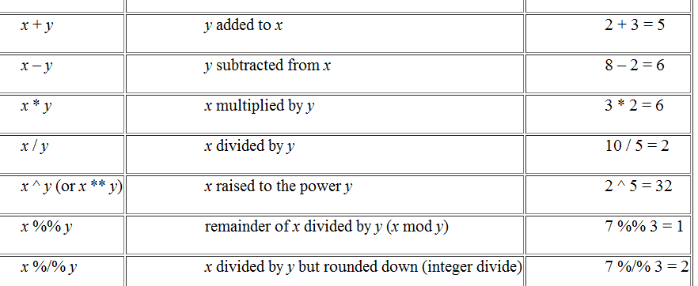

> **calculate**:

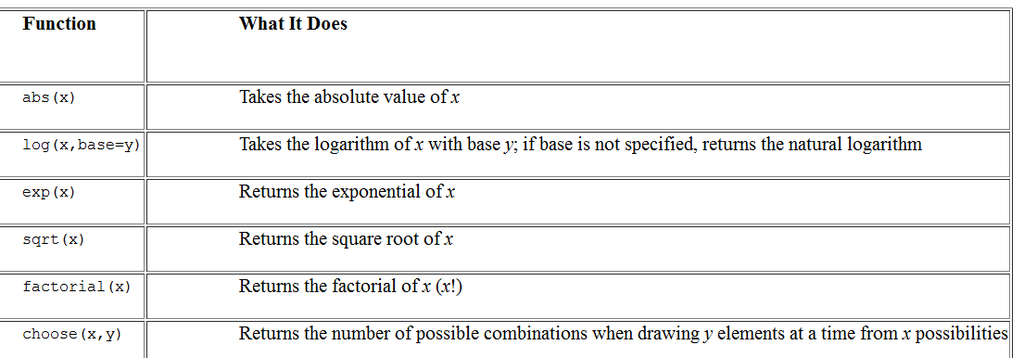

### Rounding numbers

```r
round(123.456,digits=2)
```

```
## [1] 123.46
```

```r
round(-123.456,digits=-2) # pay attention to what digits = really mean
```

```
## [1] -100
```

```r
# If you want to specify the number of significant digits to be retained, regardless of the size of the number, you use the signif() function instead:
signif(-123.456,digits=4)
```

```
## [1] -123.5
```

> **calculate**:

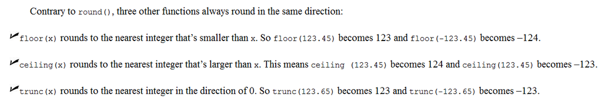

### Using trigonometric functions

```r
cos(120)
```

```
## [1] 0.814181
```

```r
cos(120*pi/180)
```

```
## [1] -0.5
```

## Calculating whole vectors

```r
`+`(2,3)
```

```
## [1] 5
```

## To infinity and beyond

### Using infinity

```r
2/0
```

```
## [1] Inf
```

```r
4 - Inf
```

```
## [1] -Inf
```

```r
is.finite(10^(305:310))
```

```
## [1]  TRUE  TRUE  TRUE  TRUE FALSE FALSE
```

```r
### Dealing with undefined outcomes
# Well, R tells you that the outcome is NaN. That result simply means Not a Number. This is R’s way of telling you that the outcome of that calculation is not defined.

Inf / Inf
```

```
## [1] NaN
```

```r
NaN + 4
```

```
## [1] NaN
```

### Dealing with missing values

> with missing values, R uses the reserved keyword NA, which stands for Not Available. You can use NA as a valid value, so you can assign it as a value as well:

> calculations with a value of NA also generally return NA as a result:

```r
x <- NA
x + 4
```

```
## [1] NA
```

```r
log(x)
```

```
## [1] NA
```

```r
is.na(x)
```

```
## [1] TRUE
```

> **infinite, NaN and NA**:

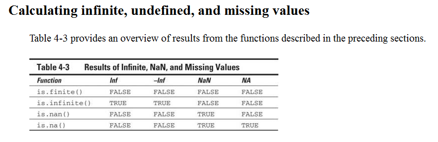

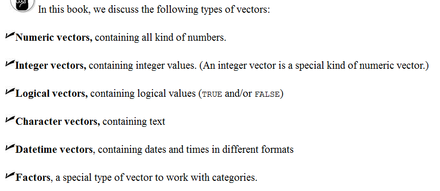

### Looking at the structure of a vector

```r
str(baskets.of.Granny)
```

```
##  num [1:6] 12 4 4 6 9 3
```

```r
length(baskets.of.Granny)
```

```
## [1] 6
```

```r
authors <- c("Andrie", "Joris")
str(authors)
```

```
##  chr [1:2] "Andrie" "Joris"
```

```r
### Testing vector types

is.numeric(baskets.of.Granny)
```

```
## [1] TRUE
```

```r
is.integer(baskets.of.Granny)
```

```
## [1] FALSE
```

```r
x <- c(4L,6L)
is.integer(x)
```

```
## [1] TRUE
```

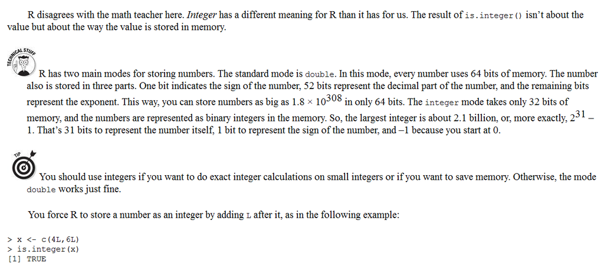

```r
## Creating vectors

seq(from = 4.5, to = 2.5, by = -0.5)
```

```
## [1] 4.5 4.0 3.5 3.0 2.5
```

```r
seq(from = -2.7, to = 1.3, length.out = 9)
```

```
## [1] -2.7 -2.2 -1.7 -1.2 -0.7 -0.2  0.3  0.8  1.3
```

```r
baskets.of.Granny <- c(12,4,4,6,9,3)
baskets.of.Geraldine <- c(5,3,2,2,12,9)

## Combining vectors

all.baskets <-c(baskets.of.Granny, baskets.of.Geraldine)
all.baskets
```

```
##  [1] 12  4  4  6  9  3  5  3  2  2 12  9
```

## Repeating vectors

```r
rep(c(0, 0, 7), times = 3)
```

```
## [1] 0 0 7 0 0 7 0 0 7
```

```r
rep(c(2, 4, 2), each = 3)
```

```
## [1] 2 2 2 4 4 4 2 2 2
```

```r
rep(c(0, 7), times = c(4,2))
```

```
## [1] 0 0 0 0 7 7
```

```r
rep(1:3,length.out=7)
```

```
## [1] 1 2 3 1 2 3 1
```

# Getting Values in and out of Vectors

```r
## Understanding indexing in R

numbers <- 30:1
numbers
```

```
##  [1] 30 29 28 27 26 25 24 23 22 21 20 19 18 17 16 15 14 13 12 11 10  9  8
## [24]  7  6  5  4  3  2  1
```

```r
## Extracting values from a vector

numbers[5]
```

```
## [1] 26
```

```r
numbers[c(5,11,3)]
```

```
## [1] 26 20 28
```

```r
indices <- c(5,11,3)
numbers[indices]
```

```
## [1] 26 20 28
```

```r
numbers[-3]
```

```
##  [1] 30 29 27 26 25 24 23 22 21 20 19 18 17 16 15 14 13 12 11 10  9  8  7
## [24]  6  5  4  3  2  1
```

```r
numbers[-(1:20)]
```

```
##  [1] 10  9  8  7  6  5  4  3  2  1
```

```r
# numbers[-1:20] # NOT RUN, gives error

## Changing values in a vector

baskets.of.Granny[3] <- 5
baskets.of.Granny
```

```
## [1] 12  4  5  6  9  3
```

```r
baskets.of.Geraldine[c(2,4)] <- 4
baskets.of.Geraldine
```

```
## [1]  5  4  2  4 12  9
```

```r
Granny.copy <- baskets.of.Granny

baskets.of.Granny[4] <- 11
baskets.of.Granny
```

```
## [1] 12  4  5 11  9  3
```

```r
baskets.of.Granny <- Granny.copy
baskets.of.Granny
```

```
## [1] 12  4  5  6  9  3
```

# Working with Logical Vectors

```r
## Comparing values

baskets.of.Granny > 5
```

```
## [1]  TRUE FALSE FALSE  TRUE  TRUE FALSE
```

```r
which(baskets.of.Granny > 5)
```

```
## [1] 1 4 5
```

```r
the.best <- baskets.of.Geraldine < baskets.of.Granny
which(the.best)
```

```
## [1] 1 3 4
```

## Using logical vectors as indices

```r
the.best
```

```
## [1]  TRUE FALSE  TRUE  TRUE FALSE FALSE
```

```r
baskets.of.Granny[the.best]
```

```
## [1] 12  5  6
```

```r
x <- c(3, 6, 1, NA, 2)
x[x > 2]
```

```
## [1]  3  6 NA
```

```r
x > 2
```

```
## [1]  TRUE  TRUE FALSE    NA FALSE
```

## Combining logical statements

> **logical calculation**:

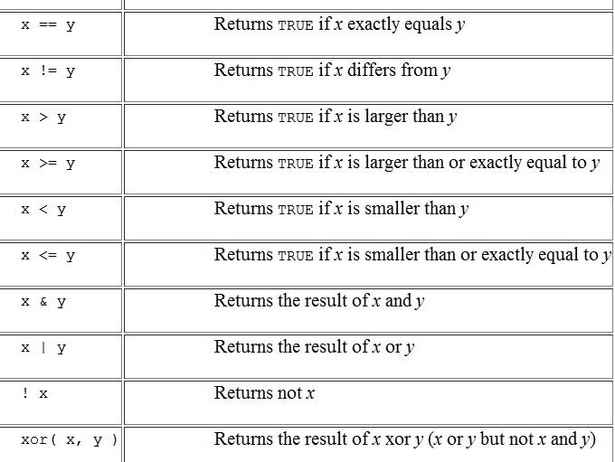

```r
min.baskets <- baskets.of.Granny == min(baskets.of.Granny)
max.baskets <- baskets.of.Granny == max(baskets.of.Granny)
min.baskets
```

```
## [1] FALSE FALSE FALSE FALSE FALSE  TRUE
```

```r
max.baskets
```

```
## [1]  TRUE FALSE FALSE FALSE FALSE FALSE
```

```r
# This method actually isn’t the most efficient way to find those values. You see how to do things like this more efficiently with the match() function in Chapter 13. But this example clearly shows you how vectorization works for logical operators.
min.baskets | max.baskets
```

```
## [1]  TRUE FALSE FALSE FALSE FALSE  TRUE
```

```r
x
```

```
## [1]  3  6  1 NA  2
```

```r
x[!is.na(x)]
```

```
## [1] 3 6 1 2
```

## Summarizing logical vectors

> In addition, you have an easy way to figure out whether any value in a logical vector is TRUE. Very conveniently, the function that performs that task is called any(). To ask R whether Granny was better than Geraldine in any game, use this code:

> We told you that Granny rocks! Well, okay, this result is a bit unfair for Geraldine, so you should check whether Granny was better than Geraldine in all the games. The R function you use for this purpose is called — surprise, surprise — all(). To find out whether Granny was always better than Geraldine, use the following code:

```r
the.best
```

```
## [1]  TRUE FALSE  TRUE  TRUE FALSE FALSE
```

```r
sum(the.best)
```

```
## [1] 3
```

```r
any(the.best)
```

```
## [1] TRUE
```

```r
all(the.best)
```

```
## [1] FALSE
```

### Summarizing a vector

```r
baskets.of.Granny
```

```
## [1] 12  4  5  6  9  3
```

```r
baskets.of.Geraldine
```

```
## [1]  5  4  2  4 12  9
```

```r
min(baskets.of.Granny)
```

```
## [1] 3
```

```r
max(baskets.of.Granny)
```

```
## [1] 12
```

```r
sum(baskets.of.Granny,baskets.of.Geraldine)
```

```
## [1] 75
```

```r
x <- c(3,6,2,NA,1)
sum(x)
```

```
## [1] NA
```

```r
sum(x,na.rm=TRUE)
```

```
## [1] 12
```

### Cumulating operations

```r
cumsum(baskets.of.Granny)
```

```
## [1] 12 16 21 27 36 39
```

```r
cummax(baskets.of.Geraldine)
```

```
## [1]  5  5  5  5 12 12
```

```r
cummin(x)
```

```
## [1]  3  3  2 NA NA
```

### Calculating differences

```r
baskets.of.Granny
```

```
## [1] 12  4  5  6  9  3
```

```r
diff(baskets.of.Granny)
```

```
## [1] -8  1  1  3 -6
```

```r
x
```

```
## [1]  3  6  2 NA  1
```

```r
diff(x)
```

```
## [1]  3 -4 NA NA
```

## Recycling arguments

```r
Granny.pointers <- c(10,2,4,0,4,1,4,2,7,2,1,2)
points <- Granny.pointers * c(2,3)
points
```

```
##  [1] 20  6  8  0  8  3  8  6 14  6  2  6
```

```r
sum(points)
```

```
## [1] 87
```

```r
sum(Granny.pointers * c(2,3))
```

```
## [1] 87
```

```r
round(diff(baskets.of.Granny) / baskets.of.Granny * 100 )
```

```
## [1]  -67   25   20   50  -67 -267
```

```r
round(diff(baskets.of.Granny) / baskets.of.Granny[1:5] * 100)
```

```
## [1] -67  25  20  50 -67
```